# Manuscript Text: Using new values, post-revision submission, now with fminsearch

## Section 2: Results

### 2.4 Stage 3: Binocular interactions

```
## Coefficient covariances computed by hccm()
## Coefficient covariances computed by hccm()
```

However the correlation between attenuation (k_AE) and suppression (AE) across all participants was r = -0.17, t(35) = 1.03, p = 0.31; and within the amblyopia group only, this was r = 0.23, t(11) = 0.78, p = 0.45.

### Data for Table 1

Table 1: Monocular attenuation and binocular interactions. Mean (SD) values are shown.

k<sub>AE</sub>:

- Control: 0.91 (0.08)
- Amblyopia: 0.42 (0.26)
  - Amblyopia vs. controls: t(14.9) = 6.68, p < 0.0001; Glass’s ∆ = 6.39
- Strabismus with equal acuity: 0.65 (0.3)

$\mu$<sub>AE</sub>:

- Control: 0.8 (0.85)
- Amblyopia: 3.04 (4.75)
- Strabismus with equal acuity: 1.86 (1.66)

$\mu$<sub>FE</sub>:

- Control: 0.9 (0.43)
- Amblyopia: 0.2 (0.36)
- Strabismus with equal acuity: 0.24 (0.34)

No main effect of group, F(1,27) = 1.77, p = 0.2, ges = 0.03 main effect of eye, F(1,27) = 4.7, p = 0.039, ges = 0.085 a significant group by eye interaction, F(1,27) = 5.42, p = 0.028, ges = 0.097 Simple main effects: no difference in uAE, F(1,27) = 3.46, p = 0.074, ges = 0.11 Simple main effects: difference in uFE, F(1,28) = 22.98, p < 0.0001, ges = 0.45

$\sigma$:

- Control: 1.1 (0.22)
- Amblyopia: 1.02 (0.16)
  - Amblyopia vs. controls: t(27.3) = 1.11, p = 0.28; Glass’s ∆ = 0.35
- Strabismus with equal acuity: 1.24 (0.24)

MSE:

- Control: 0.087 (0.045)
- Amblyopia: 0.114 (0.065)
  - Amblyopia vs. controls: t(22.8) = 1.26, p = 0.22; Glass’s ∆ = 0.58
- Strabismus with equal acuity: 0.09 (0.043)

## Supplementary section

#### Data for Supplementary Table 1

Supplementary Table 1. Stage 1 fits: Joystick calibration parameters. Mean (SD) values are shown. Statistical tests compare control vs. amblyopia groups.

delay (in seconds):

- all: 0.76 (0.29)
- Control: 0.77 (0.31)
- Amblyopia: 0.82 (0.28)
  - Amblyopia vs. controls: t(28) = 0.42, p = 0.68; Glass’s ∆ = 0.15
- Strabismus with equal acuity: 0.65 (0.27)

intercept (a):

- all: 0.17 (0.19)
- Control: 0.12 (0.14)
- Amblyopia: 0.28 (0.23)
  - Amblyopia vs. controls: t(21.2) = 2.18, p = 0.04; Glass’s ∆ = 1.09
- Strabismus with equal acuity: 0.07 (0.14)

slope (b):

- all: 1.36 (0.34)
- Control: 1.28 (0.27)
- Amblyopia: 1.51 (0.42)
  - Amblyopia vs. controls: t(21.9) = 1.75, p = 0.093; Glass’s ∆ = 0.84
- Strabismus with equal acuity: 1.27 (0.21)

Mean MSE for calibration:

- all: 0.0016 (0.0013)
- Control: 0.0012 (9e-04)
- Amblyopia: 0.0022 (0.0016)
  - Amblyopia vs. controls: t(20.1) = 2.17, p = 0.042; Glass’s ∆ = 1.15
- Strabismus with equal acuity: 0 (0.0011)

#### Regression models

##### Supplementary Table 2. Linear regression results using Group and/or kAE as predictors

Acuity (Amblyopic eye):

- Group alone: F(2,31) = 32.56, p < 0.0001 *
- k<sub>AE</sub> alone: F(1,32) = 16.4, p = 3e-04 *
- k<sub>AE</sub> after Group: F(1,30) = 0.77, p = 0.39

Stereoacuity (log10)

- Group alone: F(2,34) = 22.51, p < 0.0001 *
- k<sub>AE</sub> alone: F(1,35) = 27.24, p < 0.0001 *
- k<sub>AE</sub> after Group: F(1,33) = 4.37, p = 0.044 *
- Regression equation:
  - b<sub>0</sub> = 2.82 (SE = 0.18), t(33) = 15.92, p = 0;
  - b<sub>amblyopia</sub> = 0.1 (SE = 0.2), t(33) = 0.49, p = 0.6284;
  - b<sub>strabismus</sub> = -0.67 (SE = 0.22), t(33) = -3.05, p = 0.0045;
  - b<sub>kAE</sub> = -0.68 (SE = 0.33), t(33) = -2.09, p = 0.0443;
  - R2 = 0.62, <sub>adj</sub>R2 = 0.59, F(3,33) = 17.95, p = 0.

Contrast sensitivity (AUC, Amblyopic Eye)

- Group alone: F(2,29) = 8.5, p = 0.0012 *
- k<sub>AE</sub> alone: F(1,30) = 7.59, p = 0.0099 *
- k<sub>AE</sub> after Group: F(1,28) = 0.83, p = 0.37

Interocular balance point (letter chart)

- Group alone: F(2,29) = 16.1, p < 0.0001 *
- k<sub>AE</sub> alone: F(1,30) = 19.68, p = 0.00011 *
- k<sub>AE</sub> after Group: F(1,28) = 6.12, p = 0.02 *
- Regression equation:
  - b<sub>0</sub> = 0.97 (SE = 0.05), t(28) = 18.93, p = 0;
  - b<sub>amblyopia</sub> = -0.23 (SE = 0.06), t(28) = -3.92, p = 5^{-4};
  - b<sub>strabismus</sub> = -0.13 (SE = 0.07), t(28) = -1.97, p = 0.0594;
  - b<sub>kAE</sub> = -0.24 (SE = 0.1), t(28) = -2.47, p = 0.0197;
  - R2 = 0.61, <sub>adj</sub>R2 = 0.57, F(3,28) = 14.67, p = 0.

##### Supplementary Table 3

Acuity (Amblyopic eye):

- U<sub>AE</sub> alone: F(1,31) = 3, p = 0.093
- U<sub>AE</sub> after Group: F(1,29) = 0.28, p = 0.6
- U<sub>FE</sub> alone: F(1,32) = 5.6, p = 0.024 *
- U<sub>FE</sub> after Group: F(1,30) = 0, p = 0.94

Stereoacuity:

- U<sub>AE</sub> alone: F(1,34) = 4.75, p = 0.036 *
- U<sub>AE</sub> after Group: F(1,32) = 1.43, p = 0.24
- U<sub>FE</sub> alone: F(1,35) = 13.15, p = 0.00091 *
- U<sub>FE</sub> after Group: F(1,33) = 0.07, p = 0.79

Contrast sensitivity:

- U<sub>AE</sub> alone: F(1,29) = 4.06, p = 0.053
- U<sub>AE</sub> after Group: F(1,27) = 0.96, p = 0.34
- U<sub>FE</sub> alone: F(1,30) = 3.75, p = 0.062
- U<sub>FE</sub> after Group: F(1,28) = 0.67, p = 0.42

Interocular balance point:

- U<sub>AE</sub> alone: F(1,29) = 1.28, p = 0.27
- U<sub>AE</sub> after Group: F(1,27) = 0.01, p = 0.93
- U<sub>FE</sub> alone: F(1,30) = 2.72, p = 0.11
- U<sub>FE</sub> after Group: F(1,28) = 0.05, p = 0.83

## Appendix

### Appendix I: Comparison to alternative models

Attenuation + Normalization

- Mean error (SD): 0.096 (0.053)
- Amblyopia: 0.111 (0.064)
- Strabismus with equal acuity: 0.09 (0.043)
- Control: 0.087 (0.045)

Mean Joystick

- Mean error (SD): 0.189 (0.075)
- Amblyopia: 0.222 (0.095)
- Strabismus with equal acuity: 0.17 (0.05)
- Control: 0.171 (0.057)
- Model: F(1,35) = 220.08, p < 0.0001
- Group: F(2,35) = 1.81, p = 0.18
- Inxn: F(2,35) = 2.82, p = 0.073

Stimulus Average

- Mean error (SD): 0.15 (0.08)
- Amblyopia: 0.169 (0.089)
- Strabismus with equal acuity: 0.12 (0.058)
- Control: 0.147 (0.082)
- Model: F(1,35) = 48.41, p < 0.0001
- Group: F(2,35) = 0.89, p = 0.42
- Inxn: F(2,35) = 0.89, p = 0.42

Weighted Stimulus Average

- Mean error (SD): 0.135 (0.079)
- Amblyopia: 0.137 (0.085)
- Strabismus with equal acuity: 0.11 (0.062)
- Control: 0.146 (0.082)
- Model: F(1,35) = 23.5, p < 0.0001
- Group: F(2,35) = 0.41, p = 0.67
- Inxn: F(2,35) = 2.74, p = 0.078

Attenuation + Normalization over time

- Mean error (SD): 0.104 (0.053)
- Amblyopia: 0.115 (0.064)
- Strabismus with equal acuity: 0.09 (0.044)
- Control: 0.101 (0.047)
- Model: F(1,35) = 23.38, p < 0.0001
- Group: F(2,35) = 0.7, p = 0.5
- Inxn: F(2,35) = 5.58, p = 0.008

Ding et al. 2013, tau = 50

- Mean error (SD): 0.504 (0.16)
- Amblyopia: 0.486 (0.16)
- Strabismus with equal acuity: 0.43 (0.133)
- Control: 0.555 (0.164)
- Model: F(1,35) = 324.73, p < 0.0001
- Group: F(2,35) = 1.03, p = 0.37
- Inxn: F(2,35) = 3.05, p = 0.06

Ding et al. 2013, tau = free

- Mean error (SD): 0.502 (0.157)
- Amblyopia: 0.483 (0.154)
- Strabismus with equal acuity: 0.43 (0.132)
- Control: 0.553 (0.163)
- Model: F(1,35) = 332.17, p < 0.0001
- Group: F(2,35) = 1.04, p = 0.36
- Inxn: F(2,35) = 3.16, p = 0.055

Baker et al. 2013

- Mean error (SD): 0.105 (0.057)
- Amblyopia: 0.129 (0.069)
- Strabismus with equal acuity: 0.1 (0.045)
- Control: 0.089 (0.045)
- Model: F(1,35) = 30.12, p < 0.0001
- Group: F(2,35) = 1.51, p = 0.24
- Inxn: F(2,35) = 8.47, p = 0.001

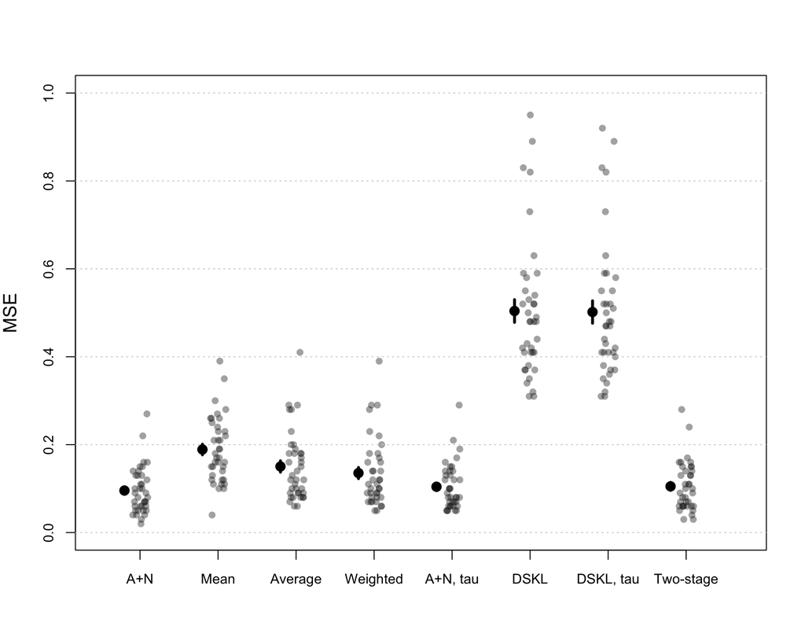

### Appendix II: Switching Models

Attenuation + Normalization

- Mean error (SD): 0.096 (0.053)
- Amblyopia: 0.111 (0.064)
- Strabismus with equal acuity: 0.09 (0.043)
- Control: 0.087 (0.045)

Stimulus Maximum

- Mean error (SD): 0.135 (0.068)
- Amblyopia: 0.174 (0.076)
- Strabismus with equal acuity: 0.13 (0.056)
- Control: 0.101 (0.046)

A+N vs. Stimulus Maximum

- Model: F(1,35) = 81.47, p < 0.0001
- Group: F(2,35) = 2.99, p = 0.063
- Inxn: F(2,35) = 12.62, p < 0.0001

Rivalry

- Mean error (SD): 0.068 (0.049)
- Amblyopia: 0.081 (0.062)
- Strabismus with equal acuity: 0.06 (0.027)
- Control: 0.062 (0.044)

Dual-mean null model

- Mean error (SD): 0.052 (0.026)
- Amblyopia: 0.063 (0.033)
- Strabismus with equal acuity: 0.04 (0.014)
- Control: 0.046 (0.023)

Rivalry vs. Dual-mean null

- Model: F(1,35) = 12.37, p = 0.001
- Group: F(2,35) = 1.28, p = 0.29
- Inxn: F(2,35) = 0.15, p = 0.86

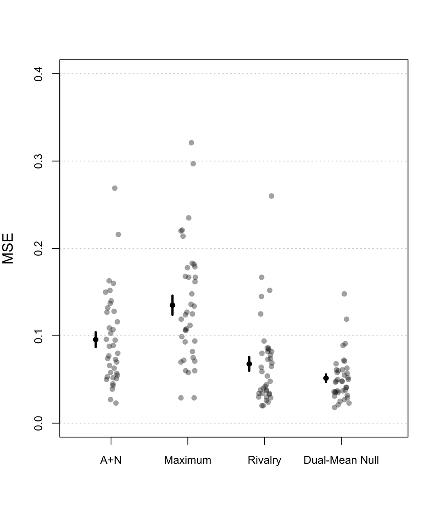